# Parkinsons_project

[figure not shown]

```
African Institute for Mathematical Sciences Rwanda
```

## **TDAGROUP PROJECT (2026)**

### **MEMBERS:**

**Katai Musonda**  
**Joachim Sinyabe Danbe**  
**Rachel Iradukunda**

```python
import pandas as pd
import numpy as np
import matplotlib.pyplot as plt
import kmapper as km
from sklearn.preprocessing import StandardScaler
from sklearn.cluster import DBSCAN
#from ucimlrepo import fetch_ucirepo
import networkx as nx
from ripser import ripser
from persim import plot_diagrams
from sklearn.neighbors import NearestNeighbors

from sklearn.neighbors import NearestNeighbors
```

# Mapper Analysis of Parkinson’s UPDRS Data ((https://archive.ics.uci.edu/dataset/189/parkinsons+telemonitoring))

**Context.**  
You are given the UCI Parkinson’s Telemonitoring dataset. A Mapper graph has been constructed using:

- **Lens function**: ( (`test_time`, `total_UPDRS`) )
- Remaining columns: Standardize the following columns(voice feature space): [`Jitter(%)`, `Jitter(Abs)`, `Jitter:RAP`, `Jitter:PPQ5`, `Jitter:DDP`, `Shimmer`, `Shimmer(dB)`, `Shimmer:APQ3`, `Shimmer:APQ5`, `Shimmer:APQ11`, `Shimmer:DDA`, `NHR`, `HNR`, `RPDE`, `DFA`, `PPE`]
- **Cover**: overlapping rectangular bins in the 2D lens
- **Clustering**: DBSCAN in standardized voice-feature space

This problem sheet is designed to not only have students generate outputs, but to encourage detailed **interpretation, reasoning, and critical thinking** about the topological and clinical insights.

```python
df = pd.read_csv("parkinsons_updrs.data")
print(f"Dataset shape: {df.shape}")
df.head()
```

```
Dataset shape: (5875, 22)
```

|  | subject# | age | sex | test_time | motor_UPDRS | total_UPDRS | Jitter(%) | Jitter(Abs) | Jitter:RAP | Jitter:PPQ5 | ... | Shimmer(dB) | Shimmer:APQ3 | Shimmer:APQ5 | Shimmer:APQ11 | Shimmer:DDA | NHR | HNR | RPDE | DFA | PPE |
| --- | --- | --- | --- | --- | --- | --- | --- | --- | --- | --- | --- | --- | --- | --- | --- | --- | --- | --- | --- | --- | --- |
| 0 | 1 | 72 | 0 | 5.6431 | 28.199 | 34.398 | 0.00662 | 0.000034 | 0.00401 | 0.00317 | ... | 0.230 | 0.01438 | 0.01309 | 0.01662 | 0.04314 | 0.014290 | 21.640 | 0.41888 | 0.54842 | 0.16006 |
| 1 | 1 | 72 | 0 | 12.6660 | 28.447 | 34.894 | 0.00300 | 0.000017 | 0.00132 | 0.00150 | ... | 0.179 | 0.00994 | 0.01072 | 0.01689 | 0.02982 | 0.011112 | 27.183 | 0.43493 | 0.56477 | 0.10810 |
| 2 | 1 | 72 | 0 | 19.6810 | 28.695 | 35.389 | 0.00481 | 0.000025 | 0.00205 | 0.00208 | ... | 0.181 | 0.00734 | 0.00844 | 0.01458 | 0.02202 | 0.020220 | 23.047 | 0.46222 | 0.54405 | 0.21014 |
| 3 | 1 | 72 | 0 | 25.6470 | 28.905 | 35.810 | 0.00528 | 0.000027 | 0.00191 | 0.00264 | ... | 0.327 | 0.01106 | 0.01265 | 0.01963 | 0.03317 | 0.027837 | 24.445 | 0.48730 | 0.57794 | 0.33277 |
| 4 | 1 | 72 | 0 | 33.6420 | 29.187 | 36.375 | 0.00335 | 0.000020 | 0.00093 | 0.00130 | ... | 0.176 | 0.00679 | 0.00929 | 0.01819 | 0.02036 | 0.011625 | 26.126 | 0.47188 | 0.56122 | 0.19361 |

5 rows × 22 columns

```python
df = df.select_dtypes(include=[np.number])
df.isnull().sum().sum()

#df = df.dropna()
#print("Data shape:", df.shape)
```

```
0
```

**There is no missing values in the data set**

```python
correlation = df['motor_UPDRS'].corr(df['total_UPDRS'])
print(f"\nUPDRS Correlation")
print(f"Correlation between motor_UPDRS and total_UPDRS: {correlation:.3f}")
```

```
UPDRS Correlation
Correlation between motor_UPDRS and total_UPDRS: 0.947
```

#### **COMMENT**

**The correlation is very high (0.947). This means motor symptoms strongly influence the total UPDRS score. In other words, when motor symptoms increase, the total score almost always increases too. So we will not use both of them.**

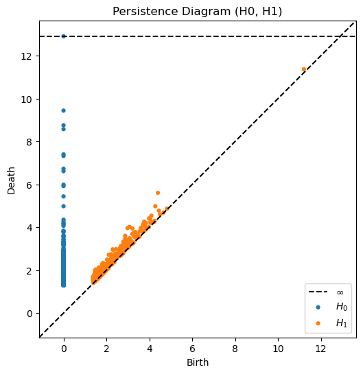

```python
features = [
    'Jitter(%)', 'Jitter(Abs)', 'Jitter:RAP', 'Jitter:PPQ5', 'Jitter:DDP',
    'Shimmer', 'Shimmer(dB)', 'Shimmer:APQ3', 'Shimmer:APQ5',
    'Shimmer:APQ11', 'Shimmer:DDA', 'NHR', 'HNR', 'RPDE', 'DFA', 'PPE'
]
lens = ['test_time', 'total_UPDRS']


scaler = StandardScaler()
X_scaled = scaler.fit_transform(df[features])
lens_data = df[lens].values


result = ripser(X_scaled, maxdim=1, n_perm= 800)
diagrams = result['dgms']


plt.figure(figsize=(12, 6))
plot_diagrams(diagrams, show=False)
plt.title("Persistence Diagram (H0, H1)")
plt.show()
```

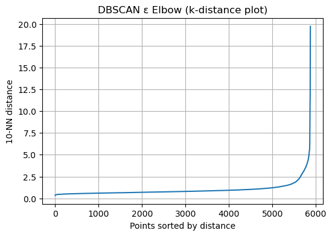

```python
def dbscan_elbow(X, min_samples=5):

    neigh = NearestNeighbors(n_neighbors=min_samples)
    neigh.fit(X)

    distances, _ = neigh.kneighbors(X)
    k_distances = distances[:, -1]
    k_distances = np.sort(k_distances)

    plt.figure(figsize=(6, 4))
    plt.plot(k_distances)
    plt.xlabel("Points sorted by distance")
    plt.ylabel(f"{min_samples}-NN distance")
    plt.title("DBSCAN ε Elbow (k-distance plot)")
    plt.grid(True)
    plt.show()

    return k_distances

arr= dbscan_elbow(X_scaled, min_samples=10)
```

## Problem 1: Connected Components

**Question.**  
How many connected components does the Mapper graph have? What might multiple components indicate in this dataset?

**Detailed Guidance / Expected Answer.**  
Compute the number of connected components. Then reflect on possible drivers:

- **Time**: Are early vs late `test_time` points in different components?
- **Severity**: Do nodes separate mainly along `total_UPDRS` or `motor_UPDRS` values?
- **Voice-feature geometry**: Are the components distinguished primarily by patterns in voice biomarkers (`Jitters`, `Shimers`,`PPE`, `RPDE`, `HNR`, etc.)?

You should **discuss all three (time, severity, and voice-features) potential contributors** with supporting evidence from node statistics.

```python
mapper = km.KeplerMapper(verbose=1)

graph = mapper.map(
    lens_data,
    X_scaled,
    cover=km.Cover(n_cubes=10, perc_overlap=0.3),
    clusterer=DBSCAN(eps=2.5, min_samples=10)
)

nx_graph = km.adapter.to_nx(graph)
n_components = nx.number_connected_components(nx_graph)

print(f"\n Mapper Graph")
print(f"Total Nodes: {len(nx_graph.nodes)}")
print(f"Total Edges: {len(nx_graph.edges)}")
print(f"Number of Connected Components: {n_components}")


html = mapper.visualize(graph,
    path_html="parkinsons_mapper.html",
    title="Parkinson's Telemonitoring Mapper Graph",
    color_values=df['total_UPDRS'].values,
    color_function_name='Total UPDRS',
    custom_tooltips=df['motor_UPDRS'].values
)

from kmapper import jupyter
jupyter.display("parkinsons_mapper.html")
```

```
KeplerMapper(verbose=1)
Mapping on data shaped (5875, 16) using lens shaped (5875, 2)

Creating 100 hypercubes.

Created 260 edges and 91 nodes in 0:00:06.480616.

 Mapper Graph
Total Nodes: 91
Total Edges: 260
Number of Connected Components: 2
Wrote visualization to: parkinsons_mapper.html
```

[interactive chart not shown]

```python
components = list(nx.connected_components(nx_graph))
voice_features = ['Jitter(%)', 'Shimmer', 'PPE', 'RPDE', 'HNR']

comp_stats = []
for i, comp in enumerate(components):

    comp_indices = []
    for node in comp:
        comp_indices.extend(graph['nodes'][node])

    comp_data = df.iloc[comp_indices]

    stats = {
        'Component': i+1,
        'Nodes': len(comp),
        'Patients': len(comp_indices),
        'Mean_time': comp_data['test_time'].mean(),
        'Std_time': comp_data['test_time'].std(),
        'Mean_total_UPDRS': comp_data['total_UPDRS'].mean(),
        'Std_total_UPDRS': comp_data['total_UPDRS'].std(),
        'Mean_motor_UPDRS': comp_data['motor_UPDRS'].mean(),
    }
    for feature in voice_features:
        stats[f'{feature}_mean'] = comp_data[feature].mean()

    comp_stats.append(stats)

    print(f"Component {i+1}")
    print(f"Nodes: {len(comp)}, Patients: {len(comp_indices)}")
    print(f"Time - Mean: {stats['Mean_time']:.2f}, Std: {stats['Std_time']:.2f}")
    print(f"Total UPDRS - Mean: {stats['Mean_total_UPDRS']:.2f}, Std: {stats['Std_total_UPDRS']:.2f}")
    print(f"Motor UPDRS - Mean: {stats['Mean_motor_UPDRS']:.2f}")
    print("Voice Features:")
    for feature in voice_features:
        print(f"  {feature}: {stats[f'{feature}_mean']:.4f}")
    print()

if len(comp_stats) == 2:
    print("Comparison Between Components")
    print(f"Time difference: {abs(comp_stats[0]['Mean_time'] - comp_stats[1]['Mean_time']):.2f}")
    print(f"UPDRS difference: {abs(comp_stats[0]['Mean_total_UPDRS'] - comp_stats[1]['Mean_total_UPDRS']):.2f}")
    print("\nVoice feature differences:")
    for feature in voice_features:
        diff = abs(comp_stats[0][f'{feature}_mean'] - comp_stats[1][f'{feature}_mean'])
        print(f"  {feature}: {diff:.4f}")
```

```
Component 1
Nodes: 90, Patients: 11013
Time - Mean: 94.40, Std: 52.98
Total UPDRS - Mean: 28.87, Std: 10.29
Motor UPDRS - Mean: 21.14
Voice Features:
  Jitter(%): 0.0053
  Shimmer: 0.0294
  PPE: 0.2099
  RPDE: 0.5341
  HNR: 22.2330

Component 2
Nodes: 1, Patients: 12
Time - Mean: 161.87, Std: 3.65
Total UPDRS - Mean: 7.00, Std: 0.00
Motor UPDRS - Mean: 5.09
Voice Features:
  Jitter(%): 0.0045
  Shimmer: 0.0235
  PPE: 0.1698
  RPDE: 0.4469
  HNR: 24.0384

Comparison Between Components
Time difference: 67.47
UPDRS difference: 21.87

Voice feature differences:
  Jitter(%): 0.0008
  Shimmer: 0.0058
  PPE: 0.0402
  RPDE: 0.0871
  HNR: 1.8054
```

#### **COMMENT**

**Time (test_time):** Component 2 has later mean time (161.87 vs 94.40 weeks, difference = 67.47). Time shows some separation.

**Severity (UPDRS):** Component 2 has much lower severity (7.00 vs 28.87, difference = 21.87). This is the strongest separator. Component 2 represents healthier/milder patients.

**Voice features:** Small to moderate differences (Jitter, Shimmer, PPE, RPDE, HNR). Voice features show some distinction but less dramatic than UPDRS.

Component 2 is a small outlier group (1 node, 12 patients) of healthier patients at later time points. Component 1 is the main population (90 nodes, 11013 patients) with typical disease severity. Severity is the primary driver of separation, with time and voice features playing secondary roles.

## Problem 2: Node Degree and Hubs

**Question.**  
Identify nodes with unusually high degree (many edges). What do such nodes represent?

**Detailed Guidance / Expected Answer.**  
High-degree nodes are hubs that connect multiple clusters. You should compute:

- Node degree distribution
- Identify hub nodes

Interpretation:

- Hubs may represent **common disease states**, which multiple patient trajectories pass through.
- Examine `test_time` and `total_UPDRS` of hubs: do they correspond to **intermediate disease severity**?
- Compare hub voice-feature profiles to non-hub nodes to identify **stable speech patterns**.

Have a discussion on how hub nodes relate to both **temporal progression** and **phenotypic density (that is clusters of patients who share similar patterns in the measured features, particularly the voice features (Jitter, Shimmer, HNR, PPE, RPDE, DFA, etc.), regardless of their disease severity or time point.)**.

```python
degrees = dict(nx_graph.degree())
node_degrees = pd.DataFrame(list(degrees.items()), columns=['Node', 'Degree'])
node_degrees = node_degrees.sort_values('Degree', ascending=False)

threshold = node_degrees['Degree'].quantile(0.9)
hub_nodes = node_degrees[node_degrees['Degree'] >= threshold]['Node'].values

print(f"\nHub threshold (90th percentile): {threshold}")
print(f"Number of hub nodes: {len(hub_nodes)}")

hub_data = []
for node_id in hub_nodes:
    node_indices = graph['nodes'][node_id]
    hub_data.append({
        'Node': node_id,
        'Size': len(node_indices),
        'Mean_UPDRS': df.iloc[node_indices]['total_UPDRS'].mean(),
        'Mean_time': df.iloc[node_indices]['test_time'].mean()
    })

hub_df = pd.DataFrame(hub_data)
print("\nHub Node Characteristics:")
print(hub_df.head(10))
```

```
Hub threshold (90th percentile): 8.0
Number of hub nodes: 30

Hub Node Characteristics:
              Node  Size  Mean_UPDRS   Mean_time
0  cube46_cluster0   168   37.538214   92.588232
1  cube62_cluster0   236   19.867530  139.020085
2  cube44_cluster0   190   28.092216   94.918932
3  cube23_cluster0   277   24.620552   50.001202
4  cube24_cluster0   212   28.696241   49.951363
5  cube25_cluster0   161   32.522888   50.232714
6  cube26_cluster0   225   38.899613   50.935698
7  cube57_cluster0   162   43.025747  116.946420
8  cube56_cluster0    99   37.258616  114.569697
9  cube55_cluster0   172   33.416686  116.686744
```

#### **COMMENT**

The hub threshold is 8 connections (90th percentile). This means nodes with 8 or more connections are considered hubs.

```python
non_hub_nodes = node_degrees[node_degrees['Degree'] < threshold]['Node'].values
non_hub_indices = []
for n in non_hub_nodes:
    non_hub_indices.extend(graph['nodes'][n])

voice_features = ['Jitter(%)', 'Shimmer', 'HNR', 'PPE', 'RPDE']
hub_indices = [idx for node_id in hub_nodes for idx in graph['nodes'][node_id]]

hub_voice_mean = df.iloc[hub_indices][voice_features].mean()
non_hub_voice_mean = df.iloc[non_hub_indices][voice_features].mean()

comparison_df = pd.DataFrame({
    'Hub Mean': hub_voice_mean,
    'Non-Hub Mean': non_hub_voice_mean,
    'Diff (%)': ((hub_voice_mean - non_hub_voice_mean) / non_hub_voice_mean) * 100
})
print("\nVoice Feature Comparison (Hubs vs Non-Hubs):")
print(comparison_df)
```

```
Voice Feature Comparison (Hubs vs Non-Hubs):
            Hub Mean  Non-Hub Mean  Diff (%)
Jitter(%)   0.005376      0.005244  2.526556
Shimmer     0.029480      0.029212  0.918469
HNR        22.108831     22.404221 -1.318456
PPE         0.210138      0.209531  0.289596
RPDE        0.538218      0.528254  1.886154
```

#### **COMMENT**

The differences in voice features between hubs and non-hubs are very small (all under 3%).

This means that Hubs are not defined by extreme or unique voice values.

They do not represent special vocal conditions.

Instead, they are structurally important in the graph.

## Problem 3: Monotonicity of Disease Severity

**Question.**  
Along long paths in the Mapper graph, does `total_UPDRS` increase monotonically?

**Detailed Guidance / Expected Answer.**

- Calculate mean `total_UPDRS` per node along paths.
- Plot or list values to visualize trends.

You have a discussion on how graph paths link to **both temporal and phenotypic interpretation**, discussing why exact monotonicity is unrealistic in real clinical datasets.

```
Longest path length: 15
Path nodes: ['cube19_cluster0', 'cube29_cluster0', 'cube39_cluster0', 'cube49_cluster0', 'cube59_cluster0', 'cube48_cluster0', 'cube47_cluster0', 'cube36_cluster0', 'cube25_cluster0', 'cube14_cluster0', 'cube3_cluster0', 'cube12_cluster0', 'cube21_cluster0', 'cube30_cluster0', 'cube40_cluster0']
UPDRS values: ['54.33', '54.58', '54.83', '54.89', '52.52', '47.55', '41.82', '38.68', '32.52', '28.40', '24.38', '18.06', '15.16', '8.27', '7.63']
```

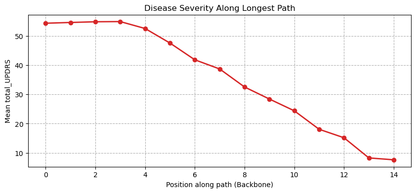

```
Monotonicity: 3/14 transitions show increase
```

```python
import matplotlib.pyplot as plt
import networkx as nx

node_updrs = {}
for node_id in graph['nodes']:
    node_indices = graph['nodes'][node_id]
    node_updrs[node_id] = df.iloc[node_indices]['total_UPDRS'].mean()

longest_path = []
max_length = 0

for component in nx.connected_components(nx_graph):
    subgraph = nx_graph.subgraph(component)

    if len(subgraph.nodes) > 1:
        diameter_val = nx.diameter(subgraph)

        periphery = nx.periphery(subgraph)
        if len(periphery) >= 2:
            path = nx.shortest_path(subgraph, periphery[0], periphery[1])
            if len(path) > max_length:
                longest_path = path  # FIXED: Removed the comma here
                max_length = len(path)


if longest_path:
    path_updrs = [node_updrs[node] for node in longest_path]

    print(f"Longest path length: {len(longest_path)}")
    print(f"Path nodes: {longest_path}")
    print(f"UPDRS values: {[f'{x:.2f}' for x in path_updrs]}")

    plt.figure(figsize=(10, 4))
    plt.plot(path_updrs, marker='o', color='tab:red', linewidth=2)
    plt.xlabel('Position along path (Backbone)')
    plt.ylabel('Mean total_UPDRS')
    plt.title('Disease Severity Along Longest Path')
    plt.grid(True, linestyle='--')
    plt.show()

    transitions = len(path_updrs) - 1
    if transitions > 0:
        increases = sum([path_updrs[i+1] > path_updrs[i] for i in range(transitions)])
        print(f"\nMonotonicity: {increases}/{transitions} transitions show increase")
    else:
        print("\nPath too short to calculate monotonicity.")
else:
    print("No path found between nodes.")
```

#### **COMMENT**

(1) patients have variable symptoms day-to-day.

(2) paths represent similar voice features not just time order and

(3) different patients progress at different rates.

## Problem 4: Temporal Mixing Within Nodes

**Question.**  
Do some nodes contain data points with a wide spread of `test_time` values? What does this imply?

**Detailed Guidance / Expected Answer.**

- Compute max-min `test_time` for each node.
- Nodes with large time spread suggest **temporal heterogeneity**, where patients at different time points share similar voice features.

Have a discussion on the clinical implications of this problem:

```
Nodes with largest temporal spread:
               Node  Size  Time_spread  Min_time  Max_time
13  cube14_cluster0   246       31.068    13.306    44.374
21  cube22_cluster0   138       30.910    35.449    66.359
74  cube75_cluster0   142       30.750   144.870   175.620
71  cube72_cluster0   202       30.550   144.910   175.460
73  cube74_cluster0   336       30.520   144.870   175.390
22  cube23_cluster0   277       30.440    35.303    65.743
61  cube62_cluster0   236       30.440   123.820   154.260
12  cube13_cluster0   259       30.409    13.306    43.715
33  cube34_cluster0   184       30.311    57.276    87.587
49  cube50_cluster0    75       30.190   101.680   131.870

Average time spread: 25.55 weeks
Max time spread: 31.07 weeks
```

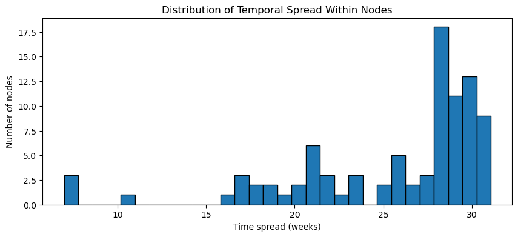

```python
time_spread = []
for node_id in graph['nodes']:
    node_indices = graph['nodes'][node_id]
    times = df.iloc[node_indices]['test_time'].values
    spread = times.max() - times.min()
    time_spread.append({
        'Node': node_id,
        'Size': len(node_indices),
        'Time_spread': spread,
        'Min_time': times.min(),
        'Max_time': times.max()
    })

time_df = pd.DataFrame(time_spread).sort_values('Time_spread', ascending=False)

print("Nodes with largest temporal spread:")
print(time_df.head(10))

print(f"\nAverage time spread: {time_df['Time_spread'].mean():.2f} weeks")
print(f"Max time spread: {time_df['Time_spread'].max():.2f} weeks")


plt.figure(figsize=(10, 4))
plt.hist(time_df['Time_spread'], bins=30, edgecolor='black')
plt.xlabel('Time spread (weeks)')
plt.ylabel('Number of nodes')
plt.title('Distribution of Temporal Spread Within Nodes')
plt.show()
```

## Problem 5: Branches as Phenotypes

**Question.**  
Do different branches of the Mapper graph correspond to different voice-feature profiles?

**Detailed Guidance / Expected Answer.**

- Select nodes from distinct branches and compute mean/variance of key features (`PPE`, `RPDE`, `HNR`, Jitter, Shimmer).
- Identify which features are most different between branches.
- Discuss whether branches are correlated with severity, time, or both.

Give some follow-up discussion on the implication of this problem.

```python
components = list(nx.connected_components(nx_graph))
print(f"Number of branches (connected components): {len(components)}")

voice_features = ['PPE', 'RPDE', 'HNR', 'Jitter(%)', 'Shimmer']

branch_profiles = []
for i, component in enumerate(components):

    branch_indices = []
    for node in component:
        branch_indices.extend(graph['nodes'][node])

    branch_data = df.iloc[branch_indices]

    profile = {'Branch': i, 'Size': len(branch_indices)}
    for feature in voice_features:
        profile[f'{feature}_mean'] = branch_data[feature].mean()
    profile['UPDRS_mean'] = branch_data['total_UPDRS'].mean()
    profile['Time_mean'] = branch_data['test_time'].mean()

    branch_profiles.append(profile)

branch_df = pd.DataFrame(branch_profiles)
print("\nBranch Voice Feature Profiles:")
print(branch_df)


if len(components) == 2:
    print("\nComparison Between Two Branches")
    for feature in voice_features:
        diff = abs(branch_df.iloc[0][f'{feature}_mean'] - branch_df.iloc[1][f'{feature}_mean'])
        print(f"{feature}: difference = {diff:.4f}")
```

```
Number of branches (connected components): 2

Branch Voice Feature Profiles:
   Branch   Size  PPE_mean  RPDE_mean   HNR_mean  Jitter(%)_mean  \
0       0  11013  0.209923   0.534058  22.232980        0.005321
1       1     12  0.169765   0.446936  24.038417        0.004478

   Shimmer_mean  UPDRS_mean   Time_mean
0      0.029372   28.872755   94.395198
1      0.023537    7.000000  161.865000

Comparison Between Two Branches
PPE: difference = 0.0402
RPDE: difference = 0.0871
HNR: difference = 1.8054
Jitter(%): difference = 0.0008
Shimmer: difference = 0.0058
```

## Problem 6: Sensitivity to the Cover

**Question.**  
How does the Mapper graph change when the number of cubes or overlap is slightly modified? What sensitivity to DBSCAN parameters like `eps`?

**Detailed Guidance / Expected Answer.**

- Compare node/edge counts and graph connectivity for small parameter changes.
- Discuss **persistent structures (structures like nodes size, vertex degrees distribution, cycles, connectivity etc. that remains after small modifications in parameters)** vs **fragile structures**.

```
Mapping on data shaped (5875, 16) using lens shaped (5875, 2)

Creating 100 hypercubes.

Created 260 edges and 91 nodes in 0:00:06.856269.
Mapping on data shaped (5875, 16) using lens shaped (5875, 2)

Creating 64 hypercubes.

Created 177 edges and 63 nodes in 0:00:04.959435.
Mapping on data shaped (5875, 16) using lens shaped (5875, 2)

Creating 144 hypercubes.

Created 360 edges and 131 nodes in 0:00:08.582145.
Mapping on data shaped (5875, 16) using lens shaped (5875, 2)

Creating 25 hypercubes.

Created 72 edges and 25 nodes in 0:00:01.628525.
Mapping on data shaped (5875, 16) using lens shaped (5875, 2)

Creating 400 hypercubes.

Created 635 edges and 280 nodes in 0:00:19.050266.
Mapping on data shaped (5875, 16) using lens shaped (5875, 2)

Creating 100 hypercubes.

Created 209 edges and 90 nodes in 0:00:05.678902.
Mapping on data shaped (5875, 16) using lens shaped (5875, 2)

Creating 100 hypercubes.

Created 284 edges and 93 nodes in 0:00:05.839933.
Mapping on data shaped (5875, 16) using lens shaped (5875, 2)

Creating 100 hypercubes.

Created 265 edges and 92 nodes in 0:00:05.676910.
Mapping on data shaped (5875, 16) using lens shaped (5875, 2)

Creating 100 hypercubes.

Created 266 edges and 93 nodes in 0:00:05.754717.
Parameter Sensitivity :
  Configuration  Nodes  Edges  Components  Avg_degree
0      Original     91    260           2    5.714286
1   fewer cubes     63    177           1    5.619048
2    more cubes    131    360           2    5.496183
3   fewer cubes     25     72           1    5.760000
4    more cubes    280    635          16    4.535714
5       overlap     90    209           2    4.644444
6       overlap     93    284           1    6.107527
7   smaller eps     92    265           2    5.760870
8    larger eps     93    266           2    5.720430
```

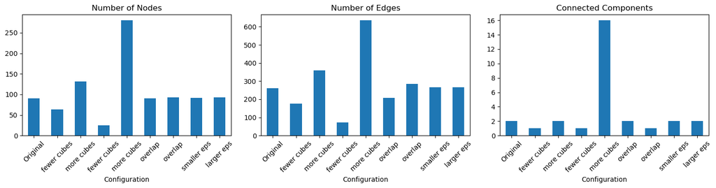

```python
param_tests = [
    {'n_cubes': 10, 'overlap': 0.3, 'eps': 2.5, 'min_samples': 10, 'name': 'Original'},

    # Small cube perturbations
    {'n_cubes': 8, 'overlap': 0.3, 'eps': 2.5, 'min_samples': 10, 'name': 'fewer cubes'},
    {'n_cubes': 12, 'overlap': 0.3, 'eps': 2.5, 'min_samples': 10, 'name': 'more cubes'},

    # Strong  cube perturbations
    {'n_cubes': 5, 'overlap': 0.3, 'eps': 2.5, 'min_samples': 10, 'name': 'fewer cubes'},
    {'n_cubes': 20, 'overlap': 0.3, 'eps': 2.5, 'min_samples': 10, 'name': 'more cubes'},

    # Overlap perturbations
    {'n_cubes': 10, 'overlap': 0.2, 'eps': 2.5, 'min_samples': 10, 'name': 'overlap'},
    {'n_cubes': 10, 'overlap': 0.4, 'eps': 2.5, 'min_samples': 10, 'name': 'overlap'},

    # eps perturbations
    {'n_cubes': 10, 'overlap': 0.3, 'eps': 2.0, 'min_samples': 10, 'name': 'smaller eps'},
    {'n_cubes': 10, 'overlap': 0.3, 'eps': 3.0, 'min_samples': 10, 'name': 'larger eps'},
]

results = []
for params in param_tests:
    test_graph = mapper.map(
        lens_data,
        X_scaled,
        cover=km.Cover(n_cubes=params['n_cubes'], perc_overlap=params['overlap']),
        clusterer=DBSCAN(eps=params['eps'], min_samples=10)
    )

    test_nx = km.adapter.to_nx(test_graph)
    n_comp = nx.number_connected_components(test_nx)

    results.append({
        'Configuration': params['name'],
        'Nodes': len(test_nx.nodes),
        'Edges': len(test_nx.edges),
        'Components': n_comp,
        'Avg_degree': sum(dict(test_nx.degree()).values()) / len(test_nx.nodes) if len(test_nx.nodes) > 0 else 0
    })

results_df = pd.DataFrame(results)
print("Parameter Sensitivity :")
print(results_df)

fig, axes = plt.subplots(1, 3, figsize=(15, 4))
results_df.plot(x='Configuration', y='Nodes', kind='bar', ax=axes[0], legend=False)
axes[0].set_title('Number of Nodes')
axes[0].tick_params(axis='x', rotation=45)

results_df.plot(x='Configuration', y='Edges', kind='bar', ax=axes[1], legend=False)
axes[1].set_title('Number of Edges')
axes[1].tick_params(axis='x', rotation=45)

results_df.plot(x='Configuration', y='Components', kind='bar', ax=axes[2], legend=False)
axes[2].set_title('Connected Components')
axes[2].tick_params(axis='x', rotation=45)

plt.tight_layout()
plt.show()
```

#### **COMMENT:**

**Stable (persistent) structures:** The main shape of the graph stays similar when we change the parameters. The big connected parts and the main hubs are still there. This means the overall structure of the data is stable.

**Unstable (fragile) structures:** The exact number of nodes changes. Some small side clusters appear or disappear. The number of edges also changes.

## Problem 7: Limitations of UPDRS as a Sole Marker

**Question.**  
Can patients with similar `total_UPDRS` values belong to very different nodes? What does this imply?

**Detailed Guidance / Expected Answer.**

- Compute variance of `total_UPDRS` within nodes. Give a discussion on significance of this problem.

```
UPDRS Variance Within Nodes:
       Mean_UPDRS  Std_UPDRS  Min_UPDRS  Max_UPDRS      Range
count   91.000000  91.000000  91.000000  91.000000  91.000000
mean    31.202953   1.542561  28.709809  33.677122   4.967313
std     13.564240   0.633808  13.938472  13.325897   1.977200
min      7.000000   0.000000   7.000000   7.000000   0.000000
25%     19.344685   1.288467  16.093500  22.048000   4.523000
50%     32.176984   1.687716  30.001000  34.581000   5.689000
75%     42.474077   1.987993  39.717000  45.890000   6.385500
max     54.889000   2.471055  54.727000  54.992000   6.774000

Nodes with high UPDRS variance (top 10):
               Node  Mean_UPDRS  Std_UPDRS  Min_UPDRS  Max_UPDRS  Range
16  cube17_cluster0   41.922406   2.471055     39.696     46.390  6.694
62  cube63_cluster0   23.606241   2.352518     20.407     27.181  6.774
57  cube58_cluster0   47.255556   2.348746     44.795     50.806  6.011
45  cube46_cluster0   37.538214   2.320596     34.806     41.413  6.607
58  cube59_cluster0   52.520425   2.310959     49.419     54.727  5.308
59  cube60_cluster0    9.860044   2.293282      7.000     12.319  5.319
7    cube7_cluster0   43.056494   2.281603     39.696     45.824  6.128
52  cube53_cluster0   24.461426   2.275492     20.491     26.974  6.483
60  cube61_cluster0   15.109536   2.256773     11.495     17.577  6.082
53  cube54_cluster0   28.052992   2.245386     25.243     32.000  6.757

Patients with UPDRS around 30
Number of nodes containing UPDRS ≈ 30: 18
Same severity appears in 18 different nodes!
```

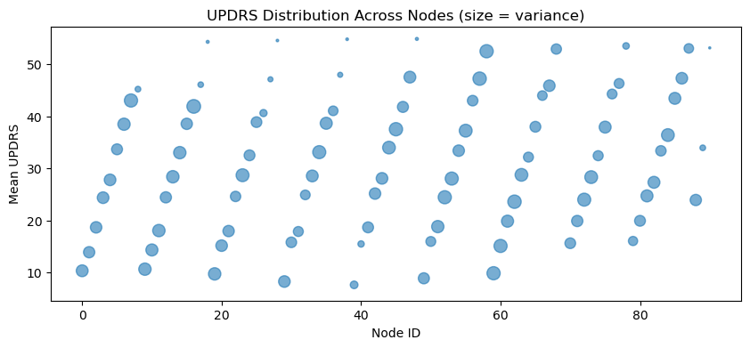

```python
node_updrs_stats = []
for node_id in graph['nodes']:
    node_indices = graph['nodes'][node_id]
    updrs_vals = df.iloc[node_indices]['total_UPDRS']
    node_updrs_stats.append({
        'Node': node_id,
        'Mean_UPDRS': updrs_vals.mean(),
        'Std_UPDRS': updrs_vals.std(),
        'Min_UPDRS': updrs_vals.min(),
        'Max_UPDRS': updrs_vals.max(),
        'Range': updrs_vals.max() - updrs_vals.min()
    })

updrs_df = pd.DataFrame(node_updrs_stats)
print("UPDRS Variance Within Nodes:")
print(updrs_df.describe())

print("\nNodes with high UPDRS variance (top 10):")
print(updrs_df.sort_values('Std_UPDRS', ascending=False).head(10))


print("\nPatients with UPDRS around 30")
target_updrs = 30
tolerance = 2

nodes_with_similar_updrs = []
for node_id in graph['nodes']:
    node_indices = graph['nodes'][node_id]
    updrs_vals = df.iloc[node_indices]['total_UPDRS']
    count = ((updrs_vals >= target_updrs - tolerance) & (updrs_vals <= target_updrs + tolerance)).sum()
    if count > 0:
        nodes_with_similar_updrs.append({'Node': node_id, 'Count': count})

print(f"Number of nodes containing UPDRS ≈ {target_updrs}: {len(nodes_with_similar_updrs)}")
print(f"Same severity appears in {len(nodes_with_similar_updrs)} different nodes!")


plt.figure(figsize=(10, 4))
plt.scatter(range(len(updrs_df)), updrs_df['Mean_UPDRS'],
           s=updrs_df['Std_UPDRS']*50, alpha=0.6)
plt.xlabel('Node ID')
plt.ylabel('Mean UPDRS')
plt.title('UPDRS Distribution Across Nodes (size = variance)')
plt.show()
```

#### **COMMENT**

**Patients with similar UPDRS scores appear in many different nodes. This shows UPDRS alone is insufficient to separate very well patients**

## Problem 8: Other observations?

```python
node_sizes = [len(graph['nodes'][node]) for node in graph['nodes']]
print("Node Size Distribution")
print(f"Mean node size: {np.mean(node_sizes):.1f}")
print(f"Median node size: {np.median(node_sizes):.1f}")
print(f"Largest node: {max(node_sizes)} patients")
print(f"Smallest node: {min(node_sizes)} patients")
```

```
Node Size Distribution
Mean node size: 121.2
Median node size: 107.0
Largest node: 336 patients
Smallest node: 12 patients
```

### **OBSERVATIONS**

**In term of Node size:** Some nodes contain many patients, while others contain only a few. This means some disease states are very common and others are rare.

**Disease progression over time:** UPDRS scores generally increase over time, which shows disease worsening. However, there is large variability between patients. Not everyone progresses the same way.

**What the graph shows overall:** The disease progression is not perfectly linear. There are multiple possible paths that patients can follow. Different groups of patients may progress in different ways.